# Data Mining Assessment - Tim Durand

# Table of Contents

```python
import warnings
warnings.filterwarnings('ignore')

# Data Wrangling
import numpy as np
import pandas as pd
pd.set_option('display.max_columns', 999)

# Data Import
from scipy.io.arff import loadarff

# Helper Functions
import AnalyseHelpers as a
import CleanseHelpers as c

# Visualisation
import matplotlib.pyplot as plt
plt.rcParams['figure.figsize'] = [8.0, 5.0]
import seaborn as sns
sns.set(font_scale=1)
# Set the styling for dataframes
dfstyles = [dict(selector="caption", props=[("font-size", "120%"),("color", "black"),("text-align", "center")])]
from IPython.display import display,HTML, display_html


# Model Pre-processing
from sklearn.preprocessing import MinMaxScaler
from sklearn.model_selection import train_test_split, GridSearchCV

#Model Metrics
from sklearn.metrics import accuracy_score, balanced_accuracy_score, confusion_matrix, roc_auc_score, classification_report, roc_curve, plot_confusion_matrix

#Models
from sklearn.tree import DecisionTreeClassifier
from sklearn.neighbors import KNeighborsClassifier
from sklearn.ensemble import BaggingClassifier, RandomForestClassifier
from sklearn.naive_bayes import GaussianNB
from sklearn.linear_model import LogisticRegression

# Cost Sensitive Models
from costcla.metrics import cost_loss, savings_score
from costcla.models import CostSensitiveLogisticRegression, CostSensitiveDecisionTreeClassifier, CostSensitiveRandomForestClassifier
from imblearn.ensemble import BalancedBaggingClassifier
from imblearn.ensemble import BalancedRandomForestClassifier

# Model Params
classweight = "balanced" #{0:0.2,1:0.8} {0:1,1:5}
randomstate = 4325
```

```python
# Import training data to df from arff file
trainingdata = 'C:/Users/emspocmgmttd/Documents/Aston/Data Mining/Assessment/CWdata/CWdata_train.arff'
testdata = 'C:/Users/emspocmgmttd/Documents/Aston/Data Mining/Assessment/CWdata/CWdata_test.arff'
raw_training_data = loadarff(trainingdata)
traindf = pd.DataFrame(raw_training_data[0])
raw_test_data = loadarff(testdata)
testdf = pd.DataFrame(raw_test_data[0])
```

```python
HTML('''<script>
code_show=true;
function code_toggle() {
 if (code_show){
 $('div.input').hide();
 } else {
 $('div.input').show();
 }
 code_show = !code_show
}
$( document ).ready(code_toggle);
</script>
<b>NOTE</b>: The code for this notebook is, by default, hidden. To display the code cells, click <a href="javascript:code_toggle()">here</a>.\r\n''')
```

**NOTE**: The code for this notebook is, by default, hidden. To display the code cells, click here.

## Abstract

The goal of this report, is to explore the key attributes, and develop several models, related to customer default payments in Taiwan. Data exploration, indicated that the financial attributes in the data, better described the target variable than the demographic attributes. Engineered features from the credit limit, balance amounts and payment status, were highlighted as some of the most important attributes when predicting a defaulting customer. The Random Forest model performed the best, from both an accuracy and cost perspective. However, the difference in accuracy for all the tuned models was negligible, therefore it was prudent to chose a less complex model; Logistic Regression. Looking at the cost of the models, the Random Forest did substantially out perform the Decision Tree, this may be due to the averaging of many trees reducing the overall error, and was chosen as the final model. Both final models performed well on the test data. However, further To take this research further, further feature engineering steps could be explored along with some Neural Network models. Python was used throughout the task, and the libraries provided some intuitive features for model fitting, tuning and feature selection.

## Introduction

The purpose of this report, is to explore a dataset related to customer banking records in the month of September 2005, from a large Taiwanese bank. Within the supplied data, approximately 22% of customers defaulted on their payments; making this an unbalanced dataset. Below is a description of the attributes contained within the data:

**Target Variable:**

- DEFAULT: Default payment status

**Predictor Variables:**

- LIMIT_BAL: The amount of credit given to the customer (NT\$).
- SEX: Customer gender, (Male or Female).
- EDUCATION: Customer education level (1=graduate school, 2=university, 3=high school, 4=others, 5=unknown, 6=unknown).
- MARRIAGE: Customer marriage status (Married, Single, Divorced, Widowed).
- AGE: Customer age in years.
- PAY_0: Repayment status one month prior (-2, -1 and 0 = no outstanding payment balance, 1=payment delay of one month, 2=payment delay for two months, etc, 9=payment delay of nine months and above).
- PAY_2 to PAY_6: Repayment status 2 to 6 months prior (same scale as PAY_0).
- BILL_AMT1 to BILL_AMT6: Bill amount on customer statement, 1 to 6 months prior (NT\$).
- PAY_AMT1 to PAY_AMT6: Amount of payment, 1 to 6 months prior (NT\$).

The objective of the assignment was to predict a customers default status as accurately as possible, in two distinct ways:

- Find a model with the best overall accuracy score (Equal costs for mis-classification).
- Find the model with the least overall cost, given the cost of a False Negative is 5 times greater than a False Positive.

The data was provided in two randomly divided sets, one for training and tuning each model and the other for the final evaluation of the best model assessed. CWdata_train.arff was used for Training and CWdata_test.arff for the final validation.

## Data Exploration

### Preliminary exploration and cleansing

```python
# Profile the data using helper function
display(a.dataprofile(traindf).style.set_table_styles(dfstyles).set_caption('Data profile: Training data'))
```

Data profile: Training data

|  | Column | Max Length Value | Max Length | Min Length Value | Min Length | Null # | Null % | Data Type | Unique Values | Row Count | Mean | Max | Min |
| --- | --- | --- | --- | --- | --- | --- | --- | --- | --- | --- | --- | --- | --- |
| 0 | LIMIT_BAL | 1e+06 | 9 | 50000 | 7 | 0 | 0 | float64 | 80 | 25000 | 167589 | 1e+06 | 10000 |
| 1 | SEX | b'M' | 4 | b'M' | 4 | 0 | 0 | string | 2 | 25000 | N/A | N/A | N/A |
| 2 | EDUCATION | b'2' | 4 | b'2' | 4 | 0 | 0 | string | 7 | 25000 | N/A | N/A | N/A |
| 3 | MARRIAGE | b'Divorced' | 11 | b'Single' | 9 | 0 | 0 | string | 4 | 25000 | N/A | N/A | N/A |
| 4 | AGE | 49 | 4 | 49 | 4 | 0 | 0 | float64 | 54 | 25000 | 35.4732 | 75 | 21 |
| 5 | PAY_0 | -1 | 4 | 2 | 3 | 0 | 0 | float64 | 11 | 25000 | -0.01508 | 8 | -2 |
| 6 | PAY_2 | -1 | 4 | 2 | 3 | 0 | 0 | float64 | 11 | 25000 | -0.13528 | 8 | -2 |
| 7 | PAY_3 | -1 | 4 | 2 | 3 | 0 | 0 | float64 | 11 | 25000 | -0.16656 | 8 | -2 |
| 8 | PAY_4 | -2 | 4 | 2 | 3 | 0 | 0 | float64 | 11 | 25000 | -0.22184 | 8 | -2 |
| 9 | PAY_5 | -1 | 4 | 2 | 3 | 0 | 0 | float64 | 10 | 25000 | -0.26608 | 8 | -2 |
| 10 | PAY_6 | -2 | 4 | 2 | 3 | 0 | 0 | float64 | 10 | 25000 | -0.28972 | 8 | -2 |
| 11 | BILL_AMT1 | -165580 | 9 | 0 | 3 | 0 | 0 | float64 | 19389 | 25000 | 51143.6 | 964511 | -165580 |
| 12 | BILL_AMT2 | 223205 | 8 | 0 | 3 | 0 | 0 | float64 | 19078 | 25000 | 49093.2 | 983931 | -69777 |
| 13 | BILL_AMT3 | 1.66409e+06 | 9 | 0 | 3 | 0 | 0 | float64 | 18796 | 25000 | 47020.6 | 1.66409e+06 | -157264 |
| 14 | BILL_AMT4 | -170000 | 9 | 0 | 3 | 0 | 0 | float64 | 18395 | 25000 | 43151.5 | 891586 | -170000 |
| 15 | BILL_AMT5 | 205730 | 8 | 0 | 3 | 0 | 0 | float64 | 17964 | 25000 | 40306.9 | 927171 | -61372 |
| 16 | BILL_AMT6 | -209051 | 9 | 0 | 3 | 0 | 0 | float64 | 17611 | 25000 | 38795.1 | 961664 | -339603 |
| 17 | PAY_AMT1 | 100467 | 8 | 0 | 3 | 0 | 0 | float64 | 7077 | 25000 | 5636.15 | 873552 | 0 |
| 18 | PAY_AMT2 | 1.21547e+06 | 9 | 0 | 3 | 0 | 0 | float64 | 7058 | 25000 | 5967.8 | 1.68426e+06 | 0 |
| 19 | PAY_AMT3 | 130000 | 8 | 0 | 3 | 0 | 0 | float64 | 6709 | 25000 | 5191.67 | 896040 | 0 |
| 20 | PAY_AMT4 | 138355 | 8 | 0 | 3 | 0 | 0 | float64 | 6201 | 25000 | 4892.38 | 621000 | 0 |
| 21 | PAY_AMT5 | 100486 | 8 | 0 | 3 | 0 | 0 | float64 | 6101 | 25000 | 4753.7 | 388071 | 0 |
| 22 | PAY_AMT6 | 232972 | 8 | 0 | 3 | 0 | 0 | float64 | 6175 | 25000 | 5249.19 | 528666 | 0 |
| 23 | DEFAULT | b'Yes' | 6 | b'No' | 5 | 0 | 0 | string | 2 | 25000 | N/A | N/A | N/A |

One can see from the initial profiling of the data, in the above table, that there are 24 columns and 25000 observations. None of the features have missing values, and there are two data types: string and float.

The string columns are encoded and therefore required decoding using a UTF-8 decoder.

```python
# Decode character string columns
objectcols = ['SEX', 'EDUCATION', 'MARRIAGE','DEFAULT']
for i in objectcols:
    traindf[i] = traindf[i].str.decode(encoding = 'UTF-8')
display(traindf[['SEX', 'EDUCATION', 'MARRIAGE','DEFAULT']].head(3).style.set_table_styles(dfstyles).set_caption('Cleansed String Columns'))
```

Cleansed String Columns

|  | SEX | EDUCATION | MARRIAGE | DEFAULT |
| --- | --- | --- | --- | --- |
| 0 | M | 2 | Married | Yes |
| 1 | F | 2 | Married | No |
| 2 | F | 2 | Married | No |

```python
print("Initial unique values in EDUCATION: ",traindf['EDUCATION'].unique())
```

```
Initial unique values in EDUCATION:  ['2' '3' '1' '0' '5' '4' '6']
```

Based on the data description, the EDUCATION variable required some cleansing. Numerical values were converted to a description of the education level, to provide better interpretability. Attribute values variables 4,5 and 6 were grouped together to form Others, as a specific education level is unknown for all these classes. An attribute value of 0 was not present in the description, but was present in the data, this value was also set to Others.

```python
# Cleanse Eductation column with replace
traindf['EDUCATION'] = traindf['EDUCATION'].replace('0','Others').replace('1','Graduate_School').replace('2','University')\
    .replace('3','High_School').replace('4','Others').replace('5','Others').replace('6','Others')
# Check results
print("Post cleanse unique values in EDUCATION: ",traindf['EDUCATION'].unique())
```

```
Post cleanse unique values in EDUCATION:  ['University' 'High_School' 'Graduate_School' 'Others']
```

Attribute values less than 0 in the PAY_n columns, are equivalent to 0; therefore all values less than 0 was set to 0.

```python
# Create list of parameter groups
paylist = ['PAY_0', 'PAY_2','PAY_3', 'PAY_4', 'PAY_5', 'PAY_6']
billlist = ['BILL_AMT1', 'BILL_AMT2','BILL_AMT3', 'BILL_AMT4', 'BILL_AMT5', 'BILL_AMT6']
amountlist = ['PAY_AMT1', 'PAY_AMT2','PAY_AMT3', 'PAY_AMT4', 'PAY_AMT5', 'PAY_AMT6']

# Cleanse paylist
for p in paylist:
    traindf[p] = traindf[p].apply(c.cleanseltzero)
```

### Class Imbalance

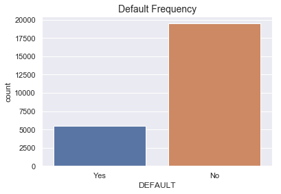

```
Percentage of Defaults:  22.06 %
```

```python
ax = sns.countplot(x="DEFAULT", data=traindf).set_title('Default Frequency', size = 14)
plt.show()
traindf['DEFAULT_NUM'] = traindf['DEFAULT'].replace('Yes',1).replace('No',0)
print("Percentage of Defaults: ",sum(traindf['DEFAULT_NUM']) / len(traindf['DEFAULT_NUM']) * 100,'%')
```

The above chart shows the frequency of the target attribute; the classes are imbalanced, with a ratio of 78:22.

### Demographic Analysis

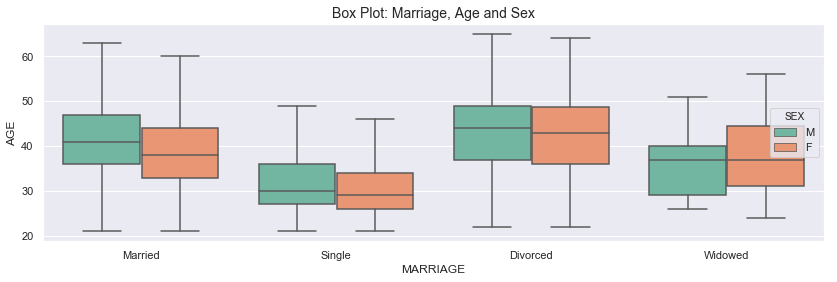

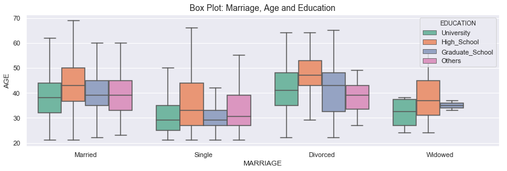

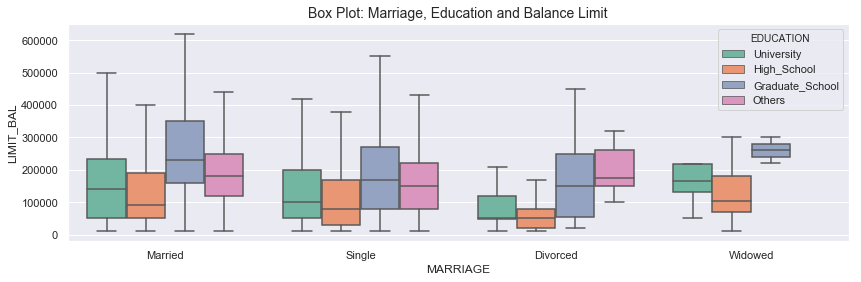

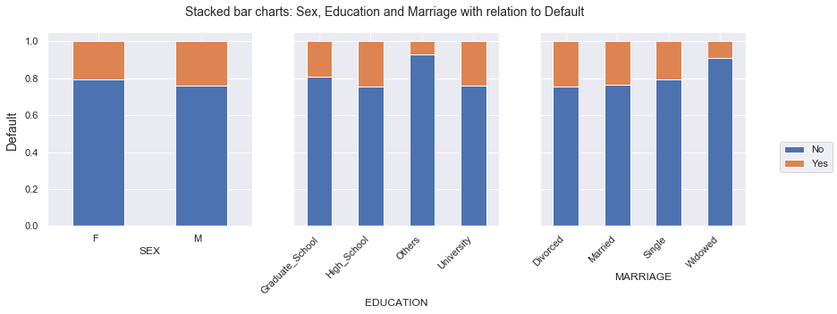

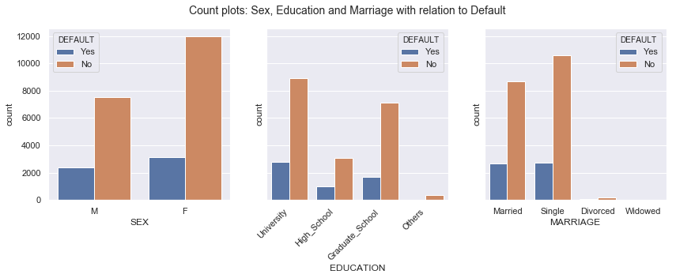

```python
plt.rcParams['figure.figsize'] = [14.0, 4.0]
ax = sns.boxplot(y='AGE', x="MARRIAGE",hue="SEX" ,data=traindf, palette="Set2", showfliers=False).set_title("Box Plot: Marriage, Age and Sex", size=14)
plt.show()

ax = sns.boxplot(y='AGE', x="MARRIAGE",hue="EDUCATION" ,data=traindf, palette="Set2",showfliers=False).set_title("Box Plot: Marriage, Age and Education", size=14)
plt.show()

ax = sns.boxplot(y='LIMIT_BAL', x="MARRIAGE",hue="EDUCATION" ,data=traindf, palette="Set2",showfliers=False).set_title("Box Plot: Marriage, Education and Balance Limit", size=14)
plt.show()

fig, axes = plt.subplots(1, 3, sharey=True)
axes = axes.flatten()
fig.suptitle('Stacked bar charts: Sex, Education and Marriage with relation to Default', size =14)

stable=pd.crosstab(traindf.SEX,traindf.DEFAULT)
stable.div(stable.sum(1).astype(float), axis=0).plot(kind='bar', stacked=True, ax = axes[0], legend=False)
plt.xlabel('SEX')
axes[0].set_xticklabels(axes[0].get_xticklabels(),rotation=0, horizontalalignment='right')

etable=pd.crosstab(traindf.EDUCATION,traindf.DEFAULT)
etable.div(etable.sum(1).astype(float), axis=0).plot(kind='bar', stacked=True, ax = axes[1], legend=False)
plt.xlabel('EDUCATION')
axes[1].set_xticklabels(axes[1].get_xticklabels(),rotation=45, horizontalalignment='right')

mtable=pd.crosstab(traindf.MARRIAGE,traindf.DEFAULT)
mtable.div(mtable.sum(1).astype(float), axis=0).plot(kind='bar', stacked=True, ax = axes[2], legend=False)
plt.xlabel('MARRIAGE')
axes[2].set_xticklabels(axes[2].get_xticklabels(),rotation=45, horizontalalignment='right')
fig.legend(stable,loc = 5)
fig.text(0.08, 0.5, 'Default', va='center', rotation='vertical', size=14)
plt.show()

fig, axes = plt.subplots(1, 3, sharey=True)
axes = axes.flatten()
fig.suptitle('Count plots: Sex, Education and Marriage with relation to Default', size =14)

sns.countplot(x="SEX", hue="DEFAULT", ax = axes[0], data=traindf)
sns.countplot(x="EDUCATION", hue="DEFAULT", ax = axes[1], data=traindf)
axes[1].set_xticklabels(axes[1].get_xticklabels(),rotation=45, horizontalalignment='right')
sns.countplot(x="MARRIAGE", hue="DEFAULT", ax = axes[2], data=traindf)
plt.show()
```

Sex does not seem to be a good predictor of whether a customer will default on their payment because there is very little variation between the two classes. Education also seems a poor predictor, because the highest variation is in an under-represented class (others). With Marriage the highest variation of Default is in the widowed class but this class, along with divorced, is under-represented.

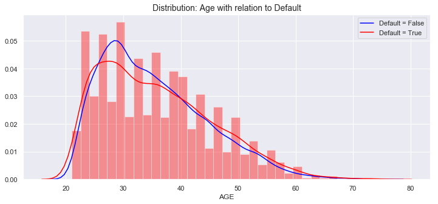

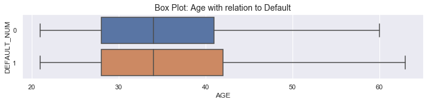

```python
NoDefault = traindf[traindf['DEFAULT_NUM'] == 0]["AGE"]
Default = traindf[traindf['DEFAULT_NUM'] == 1]["AGE"]
plt.rcParams['figure.figsize'] = [12,5]
plt.title('Distribution: Age with relation to Default', size=14)
sns.distplot(NoDefault,kde=True,bins=None, color="blue", kde_kws={"label": "Default = False"}, hist=False)
sns.distplot(Default,kde=True,bins=None, color="red",kde_kws={"label": "Default = True"})
plt.show()

plt.rcParams['figure.figsize'] = [12,2]
plt.title('Box Plot: Age with relation to Default', size=14)
sns.boxplot(x='AGE',y='DEFAULT_NUM', orient = "h",data=traindf,showfliers=False)
plt.show()
```

The mean age of customers who default is very similar to those who do not default and the distribution of the two groups is very similar so age does not look a good predictor

### Financial Analysis

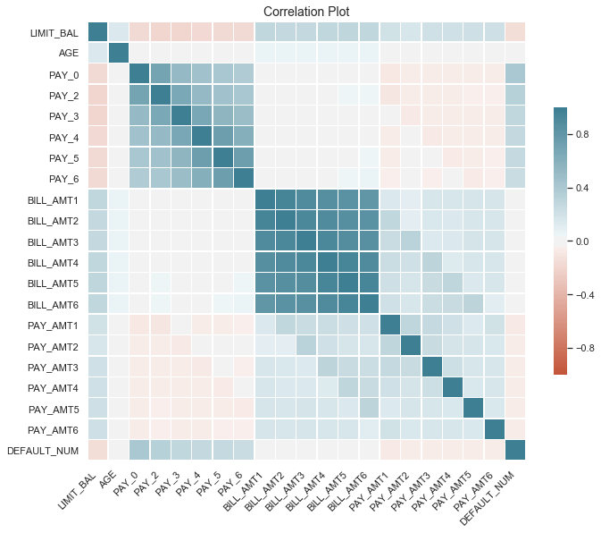

```python
plt.rcParams['figure.figsize'] = [11.0, 11.0]
# Correlation plot for Numerical variables
ax = sns.heatmap(
    traindf.corr(),
    vmin=-1, vmax=1, center=0,
    cmap=sns.diverging_palette(20, 220, n=200),
    square=True,
    linewidths=0.5 , cbar_kws={"shrink": 0.5}
)

ax.set_title("Correlation Plot",size= 14)

ax.set_xticklabels(
    ax.get_xticklabels(),
    rotation=45,
    horizontalalignment='right'
)
plt.show()
```

The above correlation plot is useful for identifying any relationships between parameters, including the target variable. Limit Balance is negatively correlated to customers who default, i.e as the balance increases the number of defaults decreases. This may mean that customers who have a good credit score, and have been good payers in the past, are given a larger limit because they can afford the re-payments. The PAY_n columns are correlated with each other, as well as BILL_AMT_n columns and the PAY_AMT_n columns. The correlation of the Pay and bill columns, infers that over time people are generally consistent with their payments and spending.  
Based on the above the balance limit and Pay_0 seem to be the most descriptive parameters with relation to the target parameter.

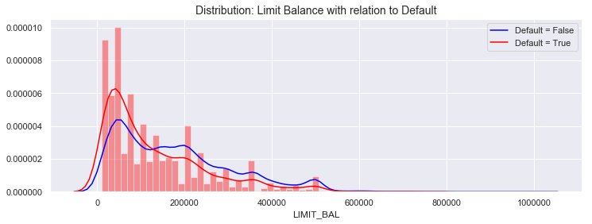

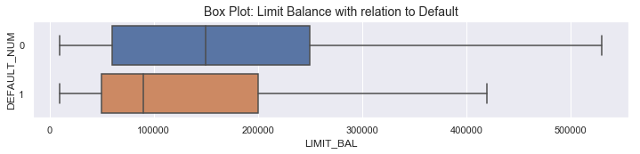

```python
NoDefault = traindf[traindf['DEFAULT_NUM'] == 0]["LIMIT_BAL"]
Default = traindf[traindf['DEFAULT_NUM'] == 1]["LIMIT_BAL"]
plt.rcParams['figure.figsize'] = [12,4]
plt.title('Distribution: Limit Balance with relation to Default', size=14)
sns.distplot(NoDefault,kde=True,bins=50, color="blue", kde_kws={"label": "Default = False"}, hist=False)
sns.distplot(Default,kde=True,bins=50, color="red",kde_kws={"label": "Default = True"})
plt.show()
plt.rcParams['figure.figsize'] = [12,2]
plt.title('Box Plot: Limit Balance with relation to Default', size=14)
sns.boxplot(x='LIMIT_BAL',y='DEFAULT_NUM', orient = "h",data=traindf,showfliers=False)
plt.show()
```

One can see from the charts above that the median balance limit is much higher for non-defaulting clients.

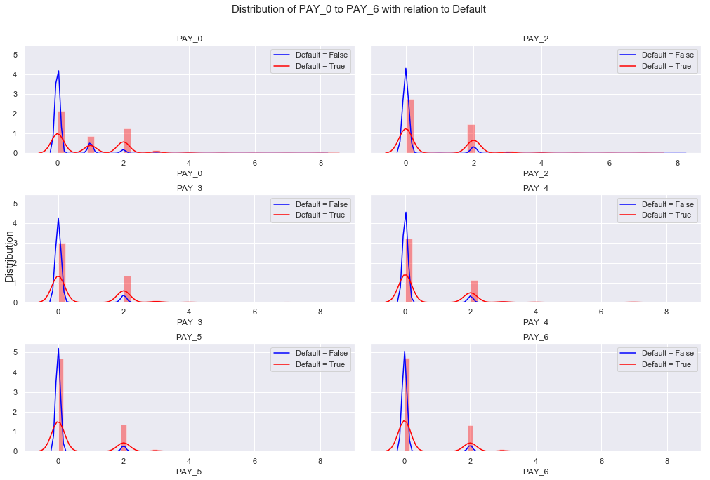

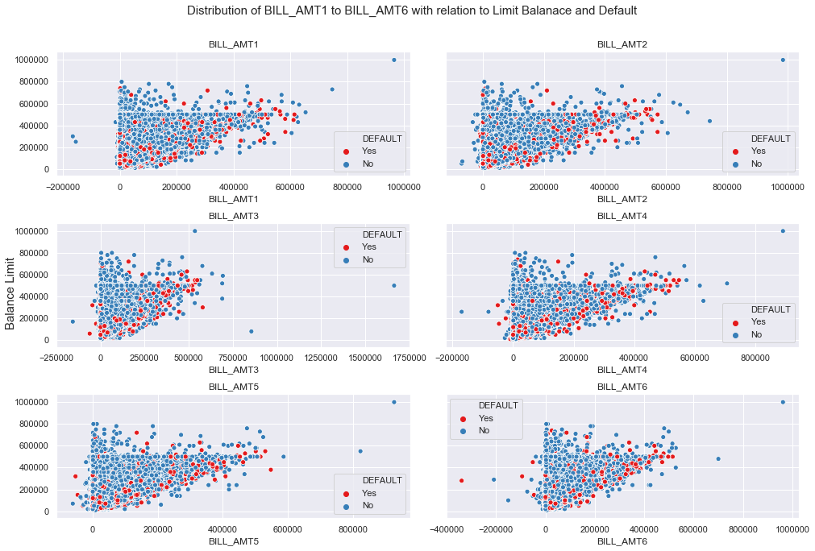

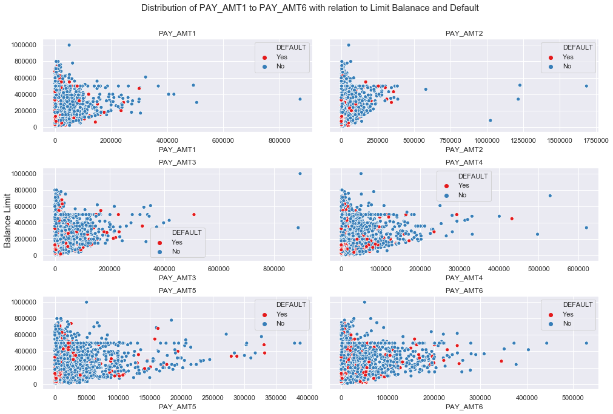

```python
plt.rcParams['figure.figsize'] = [14.0, 9.0]

# Plot the PAY_n columns against DEFAULT
fig, axes = plt.subplots(3, 2, sharey = True)
fig.suptitle('Distribution of PAY_0 to PAY_6 with relation to Default', y=1.05, fontsize=15)
axes = axes.flatten()
for i, p in enumerate(paylist, start=0):
    NoDefault = traindf[traindf['DEFAULT_NUM'] == 0][p]
    Default = traindf[traindf['DEFAULT_NUM'] == 1][p]
    ax =  sns.distplot(NoDefault,kde=True,bins=None, color="blue", kde_kws={"label": "Default = False"}, hist=False, ax=axes[i])
    ax = sns.distplot(Default,kde=True,bins=None, color="red",kde_kws={"label": "Default = True"}, ax=axes[i]).set_title(p)
    axes[i].set(ylabel="")
    plt.tight_layout()
fig.text(0, 0.5, 'Distribution', va='center', rotation='vertical', size=15)

# Plot the BILL_AMT_n columns against DEFAULT
fig, axes = plt.subplots(3, 2, sharey = True)
fig.suptitle('Distribution of BILL_AMT1 to BILL_AMT6 with relation to Limit Balanace and Default', y=1.05, fontsize=15)
axes = axes.flatten()
for i, p in enumerate(billlist, start=0):
    ax = sns.scatterplot(x=p, y="LIMIT_BAL",hue="DEFAULT", data=traindf, palette="Set1", ax=axes[i]).set_title(p)
    axes[i].set(ylabel="")
    plt.tight_layout()
fig.text(0, 0.5, 'Balance Limit', va='center', rotation='vertical', size=15)

# Plot the PAY_AMT_n columns against DEFAULT
fig, axes = plt.subplots(3, 2, sharey = True)
fig.suptitle('Distribution of PAY_AMT1 to PAY_AMT6 with relation to Limit Balanace and Default', y=1.05, fontsize=15)
axes = axes.flatten()
for i, p in enumerate(amountlist, start=0):
    ax = sns.scatterplot(x=p, y="LIMIT_BAL",hue="DEFAULT", data=traindf, palette="Set1", ax=axes[i]).set_title(p)
    axes[i].set(ylabel="")
    plt.tight_layout()
fig.text(0, 0.5, 'Balance Limit', va='center', rotation='vertical', size=15)
plt.tight_layout()
plt.show()
```

One can see from the above plots of the Pay and bill columns, that within each group of parameters there is not much variation, meaning that perhaps these dimensions can be reduced. A mean value was created for each parameter group per customer.

The Bill plot suggests, that customers with a higher bill amount in relation to their limit, tend to be in the default class. The Balance utilisation parameter was created from the mean bill amount, as a percentage of their balance.

```python
# Create mean Bill Amount
traindf['MEAN_PAY'] = traindf[paylist].mean(axis=1)
# Create mean Bill Amount
traindf['MEAN_PAY_AMT'] = traindf[amountlist].mean(axis=1)
# Create mean Bill Amount
traindf['MEAN_BILL_AMT'] = traindf[billlist].mean(axis=1)
# Create Balance Utilisation from Mean Bill Amount and the Balance Limit
traindf['BALANCE_UTILISATION'] = traindf['MEAN_BILL_AMT'] / traindf['LIMIT_BAL']
# Set any value below 0 as o
traindf['BALANCE_UTILISATION'] = traindf['BALANCE_UTILISATION'].apply(c.cleanseltzero)
traindf['BALANCE_UTILISATION'] = traindf['BALANCE_UTILISATION'].apply(c.cleansegtone)
```

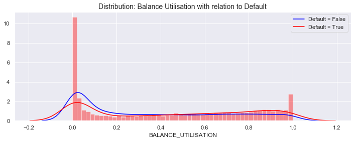

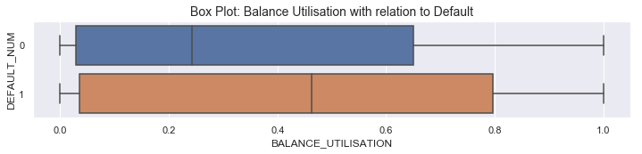

```python
NoDefault = traindf[traindf['DEFAULT_NUM'] == 0]["BALANCE_UTILISATION"]
Default = traindf[traindf['DEFAULT_NUM'] == 1]["BALANCE_UTILISATION"]
plt.rcParams['figure.figsize'] = [12,4]
plt.title('Distribution: Balance Utilisation with relation to Default', size=14)
sns.distplot(NoDefault,kde=True,bins=50, color="blue", kde_kws={"label": "Default = False"}, hist=False)
sns.distplot(Default,kde=True,bins=50, color="red",kde_kws={"label": "Default = True"})
plt.show()

plt.rcParams['figure.figsize'] = [12,2]
plt.title('Box Plot: Balance Utilisation with relation to Default', size=14)
sns.boxplot(x='BALANCE_UTILISATION',y='DEFAULT_NUM', orient = "h",data=traindf,showfliers=False)
plt.show()
```

The newly created feature shows some predictive value do to the variance shown in the charts above between the two default classes.

### Preprocessing for modelling

#### One Hot Encoding

Machine learning algorithms cannot work with categorical variables directly; the one hot encoding method was employed to convert categorical data to a binary attribute for each category.

```python
# Create dummy varibles from the categorical observations
catlist = ['SEX', 'EDUCATION', 'MARRIAGE']
traindf_prepared = pd.get_dummies(data=traindf, columns=catlist)
```

#### Scaling

```python
scalelist = ['MEAN_BILL_AMT', 'MEAN_PAY', 'MEAN_PAY_AMT', 'PAY_0','PAY_2','PAY_3','PAY_4','PAY_5', 'PAY_6','LIMIT_BAL', 'AGE','BILL_AMT1', 'BILL_AMT2', 'BILL_AMT3', 'BILL_AMT4', 'BILL_AMT5', 'BILL_AMT6', 'PAY_AMT1', 'PAY_AMT2', 'PAY_AMT3', 'PAY_AMT4', 'PAY_AMT5', 'PAY_AMT6']
newcols = list([x+'_scaled' for x in scalelist])
scaler = MinMaxScaler()
traindf_prepared[newcols] = pd.DataFrame(scaler.fit_transform(traindf_prepared[scalelist]),columns=newcols)
```

The data contains features with varying magnitudes and units; because many algorithms use the Euclidean distance between points , this can cause a higher importance to be placed on attribute values with a higher magnitude. The numeric attributes were all therefore scaled using a min/max scaler. Tree based models do not require attribute scaling, but the scaling should not have a negative effect and this kept the data consistent across the models.

#### Training and Validation split

The data was then split in two, with 70% for training and 30% for validation. The file CWdata_test.arff was not used for training or validation, and reserved for final model prediction only.

```python
# Independent columns
X = traindf_prepared.drop(scalelist, axis=1) # Drop the prescaled columns
X = X.drop(['DEFAULT', 'DEFAULT_NUM'], axis=1) # Drop the target variables

# Target column
y = traindf_prepared['DEFAULT_NUM'].astype(int)

# Split Data into training and test
X_train, X_test, y_train, y_test = train_test_split(X, y, test_size=0.3, random_state = randomstate)
print("Training Shape: X =", X_train.shape, "y =", y_train.shape)
print("Validation Shape: X =", X_test.shape, "y =",y_test.shape)
```

```
Training Shape: X = (17500, 34) y = (17500,)
Validation Shape: X = (7500, 34) y = (7500,)
```

```python
# Profile the data using helper function
display(a.dataprofile(X).style.set_table_styles(dfstyles).set_caption('Data profile: Independent Columns'))
```

Data profile: Independent Columns

|  | Column | Max Length Value | Max Length | Min Length Value | Min Length | Null # | Null % | Data Type | Unique Values | Row Count | Mean | Max | Min |
| --- | --- | --- | --- | --- | --- | --- | --- | --- | --- | --- | --- | --- | --- |
| 0 | BALANCE_UTILISATION | 0.000219231 | 22 | 0 | 3 | 0 | 0 | float64 | 23069 | 25000 | 0.37046 | 1 | 0 |
| 1 | SEX_F | 0 | 1 | 0 | 1 | 0 | 0 | uint8 | 2 | 25000 | 0.60356 | 1 | 0 |
| 2 | SEX_M | 1 | 1 | 1 | 1 | 0 | 0 | uint8 | 2 | 25000 | 0.39644 | 1 | 0 |
| 3 | EDUCATION_Graduate_School | 0 | 1 | 0 | 1 | 0 | 0 | uint8 | 2 | 25000 | 0.3516 | 1 | 0 |
| 4 | EDUCATION_High_School | 0 | 1 | 0 | 1 | 0 | 0 | uint8 | 2 | 25000 | 0.16412 | 1 | 0 |
| 5 | EDUCATION_Others | 0 | 1 | 0 | 1 | 0 | 0 | uint8 | 2 | 25000 | 0.01584 | 1 | 0 |
| 6 | EDUCATION_University | 1 | 1 | 1 | 1 | 0 | 0 | uint8 | 2 | 25000 | 0.46844 | 1 | 0 |
| 7 | MARRIAGE_Divorced | 0 | 1 | 0 | 1 | 0 | 0 | uint8 | 2 | 25000 | 0.011 | 1 | 0 |
| 8 | MARRIAGE_Married | 1 | 1 | 1 | 1 | 0 | 0 | uint8 | 2 | 25000 | 0.45416 | 1 | 0 |
| 9 | MARRIAGE_Single | 0 | 1 | 0 | 1 | 0 | 0 | uint8 | 2 | 25000 | 0.53308 | 1 | 0 |
| 10 | MARRIAGE_Widowed | 0 | 1 | 0 | 1 | 0 | 0 | uint8 | 2 | 25000 | 0.00176 | 1 | 0 |
| 11 | MEAN_BILL_AMT_scaled | 0.0615988 | 20 | 1 | 3 | 0 | 0 | float64 | 22987 | 25000 | 0.10817 | 1 | 0 |
| 12 | MEAN_PAY_scaled | 0.0277778 | 20 | 0 | 3 | 0 | 0 | float64 | 35 | 25000 | 0.0466989 | 1 | 0 |
| 13 | MEAN_PAY_AMT_scaled | 1.06268e-06 | 22 | 0 | 3 | 0 | 0 | float64 | 16589 | 25000 | 0.00841932 | 1 | 0 |
| 14 | PAY_0_scaled | 0.125 | 5 | 0 | 3 | 0 | 0 | float64 | 9 | 25000 | 0.044495 | 1 | 0 |
| 15 | PAY_2_scaled | 0.625 | 5 | 0 | 3 | 0 | 0 | float64 | 9 | 25000 | 0.03979 | 1 | 0 |
| 16 | PAY_3_scaled | 0.375 | 5 | 0 | 3 | 0 | 0 | float64 | 9 | 25000 | 0.03777 | 1 | 0 |
| 17 | PAY_4_scaled | 0.375 | 5 | 0 | 3 | 0 | 0 | float64 | 9 | 25000 | 0.032165 | 1 | 0 |
| 18 | PAY_5_scaled | 0.375 | 5 | 0 | 3 | 0 | 0 | float64 | 8 | 25000 | 0.027665 | 1 | 0 |
| 19 | PAY_6_scaled | 0.625 | 5 | 0 | 3 | 0 | 0 | float64 | 8 | 25000 | 0.02826 | 1 | 0 |
| 20 | LIMIT_BAL_scaled | 0.00606061 | 21 | 0 | 3 | 0 | 0 | float64 | 80 | 25000 | 0.159181 | 1 | 0 |
| 21 | AGE_scaled | 0.0185185 | 20 | 0.5 | 3 | 0 | 0 | float64 | 54 | 25000 | 0.268022 | 1 | 0 |
| 22 | BILL_AMT1_scaled | 0.00938597 | 20 | 0 | 3 | 0 | 0 | float64 | 19389 | 25000 | 0.191775 | 1 | 0 |
| 23 | BILL_AMT2_scaled | 0.0377495 | 20 | 0 | 3 | 0 | 0 | float64 | 19078 | 25000 | 0.112811 | 1 | 0 |
| 24 | BILL_AMT3_scaled | 0.0610189 | 20 | 0 | 3 | 0 | 0 | float64 | 18796 | 25000 | 0.112161 | 1 | 0 |
| 25 | BILL_AMT4_scaled | 0.178083 | 19 | 1 | 3 | 0 | 0 | float64 | 18395 | 25000 | 0.200786 | 1 | 0 |
| 26 | BILL_AMT5_scaled | 0.0624131 | 20 | 0 | 3 | 0 | 0 | float64 | 17964 | 25000 | 0.102857 | 1 | 0 |
| 27 | BILL_AMT6_scaled | 0.262499 | 19 | 1 | 3 | 0 | 0 | float64 | 17611 | 25000 | 0.290792 | 1 | 0 |
| 28 | PAY_AMT1_scaled | 0.000373189 | 22 | 0 | 3 | 0 | 0 | float64 | 7077 | 25000 | 0.00645199 | 1 | 0 |
| 29 | PAY_AMT2_scaled | 0.00018762 | 22 | 0 | 3 | 0 | 0 | float64 | 7058 | 25000 | 0.00354328 | 1 | 0 |
| 30 | PAY_AMT3_scaled | 0.000366055 | 22 | 0 | 3 | 0 | 0 | float64 | 6709 | 25000 | 0.00579402 | 1 | 0 |
| 31 | PAY_AMT4_scaled | 0.0002657 | 22 | 0 | 3 | 0 | 0 | float64 | 6201 | 25000 | 0.00787823 | 1 | 0 |
| 32 | PAY_AMT5_scaled | 1.03074e-05 | 22 | 0 | 3 | 0 | 0 | float64 | 6101 | 25000 | 0.0122496 | 1 | 0 |
| 33 | PAY_AMT6_scaled | 0.000429383 | 22 | 0 | 3 | 0 | 0 | float64 | 6175 | 25000 | 0.00992913 | 1 | 0 |

One can see from the above table that all values fall between 0 and 1.

## Classification Models

Four models were examined for each problem type (equal and unequal costs).

### Equal Costs

The process for each model type, was to train and validate with default settings to get a baseline, before tuning the model, and comparing the performance with the original. The equal cost models were evaluated from an accuracy perspective. The sklearn library was used for all equal cost models.

#### Model 1: Decision Tree

The Decision Tree Classifier is a good choice as a first model, because it is relatively simple and can provide insight into the important features within the data. The Decision Tree Model from the sklearn library was used.

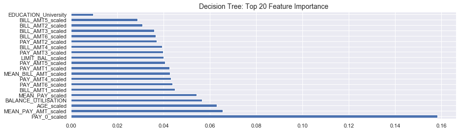

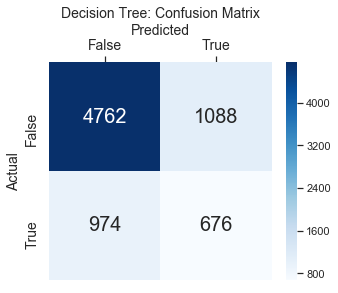

```
Classification Report
              precision    recall  f1-score   support

           0       0.83      0.81      0.82      5850
           1       0.38      0.41      0.40      1650

    accuracy                           0.73      7500
   macro avg       0.61      0.61      0.61      7500
weighted avg       0.73      0.73      0.73      7500
```

```python
dt = DecisionTreeClassifier(random_state = randomstate)
dt.fit(X_train,y_train)
dt_preds = dt.predict(X_test)
# confusion matrix
dt_cm = pd.DataFrame(confusion_matrix(y_test, dt_preds), columns=np.unique(y_test), index = np.unique(y_test))
dt_cm.index.name = 'Actual'
dt_cm.columns.name = 'Predicted'

# plot feature importance
plt.rcParams['figure.figsize'] = [14,4]
feature_importances = pd.Series(dt.feature_importances_, index=X_train.columns)
feature_importances.nlargest(20).plot(kind='barh')
plt.title("Decision Tree: Top 20 Feature Importance", size="14")
plt.show()

plt.figure(figsize=(5,4))
ax= plt.subplot()
plt.title('Decision Tree: Confusion Matrix', size=14)
sns.heatmap(dt_cm, annot=True, ax=ax, fmt = 'g',cmap='Blues', annot_kws={"size": 20});
ax.set_xlabel('Predicted', fontsize=14)
ax.xaxis.set_label_position('top')
ax.xaxis.set_ticklabels(['False', 'True'], fontsize = 14)
ax.xaxis.tick_top()
ax.set_ylabel('Actual', fontsize=14)
ax.yaxis.set_ticklabels(['False', 'True'], fontsize = 14)
plt.show()
print("Classification Report")
print(classification_report(y_test, dt_preds))
```

The above feature importance output, shows the Pay_0 is the most important feature, followed by the other financial columns; which was expected from the data exploration results. The relatively high importance of age was not expected. The categorical features have a very low feature importance. The accuracy of the model is 73%, which is the correctly classified items divided by all classified items, this seems like a good result but one has to remember that the data is not balanced. The confusion matrix gives a more detailed view of model performance.

### Feature reduction

At this point only the 10 most important features were used to re-train and predict.

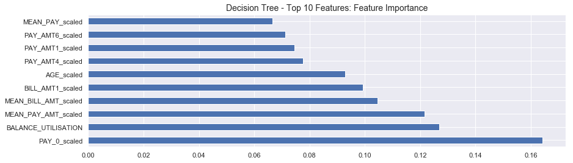

```python
# Only use top 10 Features
T10 = list(feature_importances.nlargest(10).index)
X_train = X_train[T10]
X_test = X_test[T10]

# Retrain model on Top 10
dt = DecisionTreeClassifier(random_state = randomstate)
dt.fit(X_train,y_train)
dt_preds = dt.predict(X_test)
# confusion matrix
dt_cm = pd.DataFrame(confusion_matrix(y_test, dt_preds), columns=np.unique(y_test), index = np.unique(y_test))
dt_cm.index.name = 'Actual'
dt_cm.columns.name = 'Predicted'

# plot feature importance
plt.rcParams['figure.figsize'] = [14,4]
feature_importances = pd.Series(dt.feature_importances_, index=X_train.columns)
feature_importances.nlargest(10).plot(kind='barh')
plt.title("Decision Tree - Top 10 Features: Feature Importance", size="14")
plt.show()
```

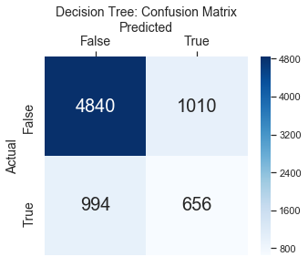

```
              precision    recall  f1-score   support

           0       0.83      0.83      0.83      5850
           1       0.39      0.40      0.40      1650

    accuracy                           0.73      7500
   macro avg       0.61      0.61      0.61      7500
weighted avg       0.73      0.73      0.73      7500
```

```python
plt.figure(figsize=(5,4))
ax= plt.subplot()
plt.title('Decision Tree: Confusion Matrix', size=14)
sns.heatmap(dt_cm, annot=True, ax=ax, fmt = 'g',cmap='Blues', annot_kws={"size": 20});
ax.set_xlabel('Predicted', fontsize=14)
ax.xaxis.set_label_position('top')
ax.xaxis.set_ticklabels(['False', 'True'], fontsize = 14)
ax.xaxis.tick_top()
ax.set_ylabel('Actual', fontsize=14)
ax.yaxis.set_ticklabels(['False', 'True'], fontsize = 14)
plt.show()
print(classification_report(y_test, dt_preds))
```

One can see from the above that the accuracy of the model does not decrease when only using 10 features. In fact, all models were trained and evaluated on all features, then just the top 10 above; the accuracy did not drop for any model.

#### Model 1: Tuning

A grid search was performed with some key hyperparameters to find the optimum settings. 3 fold cross validation was used as part of the function. Below is the list of hyperparameters and a description from the official documentation.

- max_depth (default=None): The maximum depth of the tree. If None, then nodes are expanded until all leaves are pure or until all leaves contain less than min_samples_split samples.
- max_features (default=auto): The number of features to consider when looking for the best split.
- min_samples_leaf (default=1): The minimum number of samples required to be at a leaf node. A split point at any depth will only be considered if it leaves at least min_samples_leaf training samples in each of the left and right branches. This may have the effect of smoothing the model, especially in regression.
- min_samples_split (default=2): The minimum number of samples required to split an internal node.

```python
# Create the parameter grid based on the results of random search
param_grid = {
    'max_depth': [3, 5, 10, 20, 30, 50, 70, 100, 140],
    'max_features': [None, "auto", 2, 3, 4],
    'min_samples_leaf': [1, 2, 3, 4, 5],
    'min_samples_split': [2, 4, 8, 10, 12]
}

# Instantiate the grid search model
grid_search = GridSearchCV(estimator = dt, param_grid = param_grid,
                          cv = 3, n_jobs =-1)
# Fit the model against the grid of hyperparams
grid_search.fit(X_train,y_train)

print("Best Parameters:",grid_search.best_params_)
```

```
Best Parameters: {'max_depth': 3, 'max_features': None, 'min_samples_leaf': 1, 'min_samples_split': 2}
```

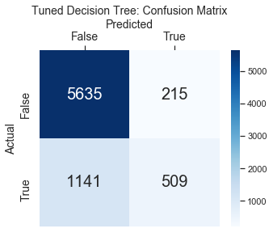

```
              precision    recall  f1-score   support

           0       0.83      0.96      0.89      5850
           1       0.70      0.31      0.43      1650

    accuracy                           0.82      7500
   macro avg       0.77      0.64      0.66      7500
weighted avg       0.80      0.82      0.79      7500
```

```python
dt_best_model = grid_search.best_estimator_
bdt_preds = dt_best_model.predict(X_test)
# confusion matrix
bdt_cm = pd.DataFrame(confusion_matrix(y_test, bdt_preds), columns=np.unique(y_test), index = np.unique(y_test))
bdt_cm.index.name = 'Actual'
bdt_cm.columns.name = 'Predicted'

# Show Confusion Matric and Accuracy
# Plot CM
plt.figure(figsize=(5,4))
ax= plt.subplot()
plt.title('Tuned Decision Tree: Confusion Matrix', size=14)
sns.heatmap(bdt_cm, annot=True, ax=ax, fmt = 'g',cmap='Blues', annot_kws={"size": 20});
ax.set_xlabel('Predicted', fontsize=14)
ax.xaxis.set_label_position('top')
ax.xaxis.set_ticklabels(['False', 'True'], fontsize = 14)
ax.xaxis.tick_top()
ax.set_ylabel('Actual', fontsize=14)
ax.yaxis.set_ticklabels(['False', 'True'], fontsize = 14)
plt.show()
print(classification_report(y_test, bdt_preds))
```

The results above confirm that the tuned decision tree has increased the accuracy by 9%, a significant improvement on the default model. The default decision tree had similar False Positive and False Negative values, but the tuned model has a slightly higher number of False Negatives and a much lower number of False Positives.

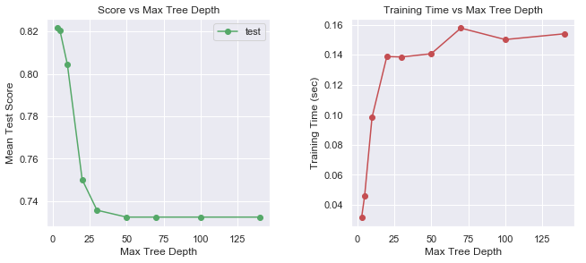

```python
# Create the parameter grid based on the results of random search
param_grid = {'max_depth': [3, 5, 10, 20, 30, 50, 70, 100, 140], 'max_features': [None], 'min_samples_leaf': [1], 'min_samples_split': [2]}

# Instantiate the grid search model
grid_search = GridSearchCV(estimator = dt, param_grid = param_grid,
                          cv = 3, n_jobs =-1)
# Fit the model against the grid of hyperparams
grid_search.fit(X_train,y_train)

a.plot_grid_results(grid_search, param='max_depth', name = 'Max Tree Depth')
```

The maximum depth is probably the most important parameter of the tree, and can be used for pre-pruning. The grid search was repeated with the optimum values from the previous search and a variable maximum depth. One can see that the test score goes down, to a point with larger trees and the training time increases.

#### Model 2: Random Forest

The Random forest is the next logical step as it fits a number of decision trees on various sub-samples of the data, then averages the results to improve accuracy and reduce over-fitting. The Random Forest Classifier was used from the Sklearn library

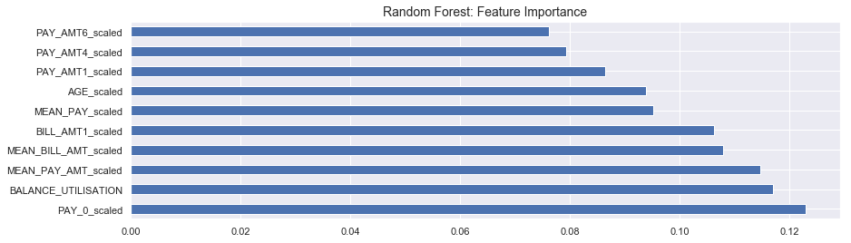

```python
rf = RandomForestClassifier(random_state = randomstate)
rf.fit(X_train,y_train)
rf_preds = rf.predict(X_test)
# confusion matrix
rf_cm = pd.DataFrame(confusion_matrix(y_test, rf_preds), columns=np.unique(y_test), index = np.unique(y_test))
rf_cm.index.name = 'Actual'
rf_cm.columns.name = 'Predicted'

# plot feature importance
plt.rcParams['figure.figsize'] = [14,4]
feature_importances = pd.Series(rf.feature_importances_, index=X_train.columns)
feature_importances.nlargest(20).plot(kind='barh')
plt.title("Random Forest: Feature Importance", size="14")
plt.show()
```

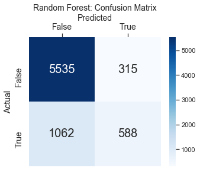

```
Classification Report
              precision    recall  f1-score   support

           0       0.84      0.95      0.89      5850
           1       0.65      0.36      0.46      1650

    accuracy                           0.82      7500
   macro avg       0.75      0.65      0.68      7500
weighted avg       0.80      0.82      0.80      7500
```

```python
# Plot CM
plt.figure(figsize=(5,4))
ax= plt.subplot()
plt.title('Random Forest: Confusion Matrix', size=14)
sns.heatmap(rf_cm, annot=True, ax=ax, fmt = 'g',cmap='Blues', annot_kws={"size": 20});
ax.set_xlabel('Predicted', fontsize=14)
ax.xaxis.set_label_position('top')
ax.xaxis.set_ticklabels(['False', 'True'], fontsize = 14)
ax.xaxis.tick_top()
ax.set_ylabel('Actual', fontsize=14)
ax.yaxis.set_ticklabels(['False', 'True'], fontsize = 14)
plt.show()

print("Classification Report")
print(classification_report(y_test, rf_preds))
```

Pay_0 is still the most important feature, followed by some of the engineered columns: Balance Utilisation and the Mean Bill and Pay amounts. The accuracy of the default model is 82%, which is comparable to the tuned decision tree model. The confusion matrix is also more similar to the tuned decision tree than the default model, but the True Positive score has improved.

#### Model 2: Tuning

The grid search was composed of the same parameters as the decision tree with the n_estimators hyperparameter added:

- n_estimators (default=100) = The number of trees in the forest.

```python
# Create the parameter grid based on the results of random search
param_grid = {
    'max_depth': [3, 5, 10, 15],
    'max_features': ["auto", 2, 4],
    'min_samples_leaf': [1, 2, 3, 5],
    'min_samples_split': [2, 4],
    'n_estimators': [80, 90, 100,110]
}

# Instantiate the grid search model
grid_search = GridSearchCV(estimator = rf, param_grid = param_grid,
                          cv = 3, n_jobs =-1)
# Fit the model against the grid of hyperparams
grid_search.fit(X_train,y_train)

print("Best Parameters:",grid_search.best_params_)
```

```
Best Parameters: {'max_depth': 10, 'max_features': 2, 'min_samples_leaf': 1, 'min_samples_split': 2, 'n_estimators': 100}
```

Tuned Random Forest: Confusion Matrix

[output not shown]

[figure not shown]

```
              precision    recall  f1-score   support

           0       0.84      0.96      0.89      5850
           1       0.70      0.34      0.46      1650

    accuracy                           0.82      7500
   macro avg       0.77      0.65      0.67      7500
weighted avg       0.81      0.82      0.80      7500
```

```python
rf_best_model = grid_search.best_estimator_
brf_preds = rf_best_model.predict(X_test)
# confusion matrix
brf_cm = pd.DataFrame(confusion_matrix(y_test, brf_preds), columns=np.unique(y_test), index = np.unique(y_test))
brf_cm.index.name = 'Actual'
brf_cm.columns.name = 'Predicted'
# Show Confusion Matrix and Accuracy
display(bdt_cm.style.set_table_styles(dfstyles).\
        set_caption('Tuned Random Forest: Confusion Matrix'))
# Plot CM
plt.figure(figsize=(5,4))
ax= plt.subplot()
plt.title('Tuned Random Forest: Confusion Matrix', size=14)
sns.heatmap(bdt_cm, annot=True, ax=ax, fmt = 'g',cmap='Blues', annot_kws={"size": 20});
ax.set_xlabel('Predicted', fontsize=14)
ax.xaxis.set_label_position('top')
ax.xaxis.set_ticklabels(['False', 'True'], fontsize = 14)
ax.xaxis.tick_top()
ax.set_ylabel('Actual', fontsize=14)
ax.yaxis.set_ticklabels(['False', 'True'], fontsize = 14)
plt.show()
print(classification_report(y_test, brf_preds))
```

The grid search found that there was no substantial improvement with new parameters. The accuracy has not improved, and the confusion matrix has only slightly changed.

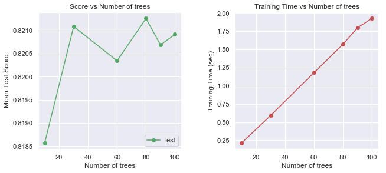

```python
# Create the parameter grid based on the results of random search
param_grid = {'n_estimators': [10, 30, 60, 80, 90, 100], 'max_depth': [10], 'max_features': ["auto"], 'min_samples_leaf': [3], 'min_samples_split': [2]}

# Instantiate the grid search model
grid_search = GridSearchCV(estimator = rf, param_grid = param_grid,
                          cv = 3, n_jobs =-1)
# Fit the model against the grid of hyperparams
grid_search.fit(X_train,y_train)

a.plot_grid_results(grid_search, param='n_estimators', name = 'Number of trees')
```

#### Model 3: K Nearest Neighbors

The K Nearest Neighbors model is one of the more simple clustering models but often provides good results.

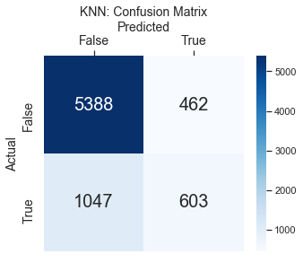

```
Classification Report
              precision    recall  f1-score   support

           0       0.84      0.92      0.88      5850
           1       0.57      0.37      0.44      1650

    accuracy                           0.80      7500
   macro avg       0.70      0.64      0.66      7500
weighted avg       0.78      0.80      0.78      7500
```

```python
knn = KNeighborsClassifier()
knn.fit(X_train,y_train)
knn_preds = knn.predict(X_test)
# confusion matrix
knn_cm = pd.DataFrame(confusion_matrix(y_test, knn_preds), columns=np.unique(y_test), index = np.unique(y_test))
knn_cm.index.name = 'Actual'
knn_cm.columns.name = 'Predicted'

# Show Confusion Matric and Accuracy
# Plot CM
plt.figure(figsize=(5,4))
ax= plt.subplot()
plt.title('KNN: Confusion Matrix', size=14)
sns.heatmap(knn_cm, annot=True, ax=ax, fmt = 'g',cmap='Blues', annot_kws={"size": 20});
ax.set_xlabel('Predicted', fontsize=14)
ax.xaxis.set_label_position('top')
ax.xaxis.set_ticklabels(['False', 'True'], fontsize = 14)
ax.xaxis.tick_top()
ax.set_ylabel('Actual', fontsize=14)
ax.yaxis.set_ticklabels(['False', 'True'], fontsize = 14)
plt.show()
print("Classification Report")
print(classification_report(y_test, knn_preds))
```

KNN performs better on a reduced number of features, this is because it is a lazy learner and requires more data with an increased number of features. The accuracy of the default model is 80%, around 2% better with the reduced feature set than the full set.

#### Model 3: Tuning

The grid search was composed of just the number of nearest neighbors(n_neighbors), the default value is 5.

```python
# Create the parameter grid
param_grid = {
    'n_neighbors': [3,5,7,9,11,13,15,17]
}

# Instantiate the grid search model
grid_search = GridSearchCV(estimator = knn, param_grid = param_grid,
                          cv = 3, n_jobs =-1)
# Fit the model against the grid of hyperparams
grid_search.fit(X_train,y_train)
print("Best Parameters:",grid_search.best_params_)
```

```
Best Parameters: {'n_neighbors': 17}
```

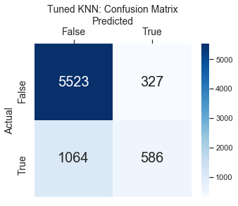

```
              precision    recall  f1-score   support

           0       0.84      0.94      0.89      5850
           1       0.64      0.36      0.46      1650

    accuracy                           0.81      7500
   macro avg       0.74      0.65      0.67      7500
weighted avg       0.80      0.81      0.79      7500
```

```python
knn_best_model = grid_search.best_estimator_
bknn_preds = knn_best_model.predict(X_test)
# confusion matrix
bknn_cm = pd.DataFrame(confusion_matrix(y_test, bknn_preds), columns=np.unique(y_test), index = np.unique(y_test))
bknn_cm.index.name = 'Actual'
bknn_cm.columns.name = 'Predicted'

# Plot CM
plt.figure(figsize=(5,4))
ax= plt.subplot()
plt.title('Tuned KNN: Confusion Matrix', size=14)
sns.heatmap(bknn_cm, annot=True, ax=ax, fmt = 'g',cmap='Blues', annot_kws={"size": 20});
ax.set_xlabel('Predicted', fontsize=14)
ax.xaxis.set_label_position('top')
ax.xaxis.set_ticklabels(['False', 'True'], fontsize = 14)
ax.xaxis.tick_top()
ax.set_ylabel('Actual', fontsize=14)
ax.yaxis.set_ticklabels(['False', 'True'], fontsize = 14)
plt.show()
print(classification_report(y_test, bknn_preds))
```

Increasing the number of neighbors increased the accuracy by around 1%. The recall is increased for non-defaulting customers, but reduced for defaulting customers; meaning the tuned model is slightly better for True Negatives, and worse for True Positives

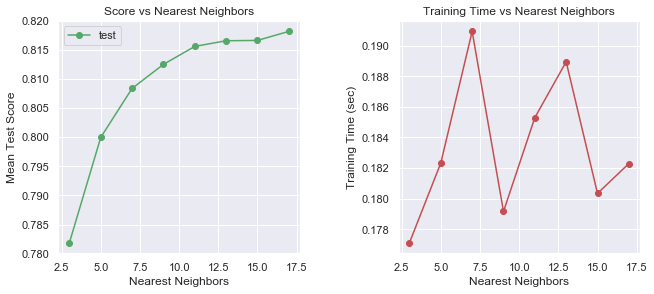

```python
a.plot_grid_results(grid_search, param='n_neighbors', name = 'Nearest Neighbors')
```

#### Model 4: Logistic Regression

The logistic regression model, in simple terms, uses a logistic function to model a binary dependent variable, it is therefore a good candidate for this task.

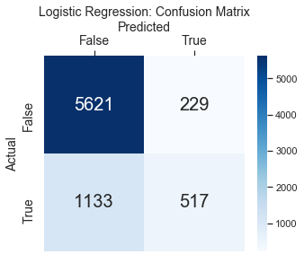

```
Classification Report
              precision    recall  f1-score   support

           0       0.83      0.96      0.89      5850
           1       0.69      0.31      0.43      1650

    accuracy                           0.82      7500
   macro avg       0.76      0.64      0.66      7500
weighted avg       0.80      0.82      0.79      7500
```

```python
lr = LogisticRegression(max_iter=200)
lr.fit(X_train,y_train)
lr_preds = lr.predict(X_test)
# confusion matrix
lr_cm = pd.DataFrame(confusion_matrix(y_test, lr_preds), columns=np.unique(y_test), index = np.unique(y_test))
lr_cm.index.name = 'Actual'
lr_cm.columns.name = 'Predicted'

# Plot CM
plt.figure(figsize=(5,4))
ax= plt.subplot()
plt.title('Logistic Regression: Confusion Matrix', size=14)
sns.heatmap(lr_cm, annot=True, ax=ax, fmt = 'g',cmap='Blues', annot_kws={"size": 20});
ax.set_xlabel('Predicted', fontsize=14)
ax.xaxis.set_label_position('top')
ax.xaxis.set_ticklabels(['False', 'True'], fontsize = 14)
ax.xaxis.tick_top()
ax.set_ylabel('Actual', fontsize=14)
ax.yaxis.set_ticklabels(['False', 'True'], fontsize = 14)
plt.show()
print("Classification Report")
print(classification_report(y_test, lr_preds))
```